# MFA analysis

Kirthana

07/11/2019

# Multiple Factor Analysis

**Data Table** MFA is used to handle multiple tables, that have different variables measuring the same observations, or same set of variables on different set of observations

**Goal:**

1. To analyze several data sets measured on the same observations
2. To provide a set of common factor scores (often called ‘compromise factor scores’)
3. To project each of the original data sets onto the compromise to analyze communalities and discrepancies.

**Note:** The number and/or nature of the variables used to describe the observations can vary from one set of variables to the other, but the observations should be the same in all the data sets.

**Key ideas**

```
* Normalization: The general idea behind MFA is to normalize each of the individual data sets so that their first
principal component has the same length (as measured by the first singular value of each data table).

* Combining the tables: data tables into a common representation of the observations sometimes called the compromise.
This compromise is obtained from a (non-normalized) PCA of the grand table obtained from the concatenation of the
normalized data tables.
```

**Interpretation**

```
1. This PCA decomposes the variance of the compromise into a set of new orthogonal variables(i.e., the principal
   components also often called dimensions, axes, factors, or even latent variables) ordered by the mount of variance
   that each component explains.

2. **Global Factor Scores**
   The coordinates of the observations on the components are called factor scores and these can be used to plot maps of
   the observations in which the observations are represented as points such that the distances in the map best reflect
   the similarities between the observations.

3. **Partial Factor Scores**
   The positions of the observations ‘as seen by’ each data set are called partial factor scores and can be also
   represented as points in the compromise map. The average of the factor scores of all the tables gives back the
   factor score of the compromise.
```

## Datasets: Survey of Autobiographical Memory(SAM) + Object-Spatial Imagery Questionnaire(OSIQ) + Big Five Inventory(BFI)

**SAM** Columns: 26 quantitative variables Episodic Memory: 8 questions (Memory for personal experiences) Semantic Memory : 6 questions (Memory for general knowledge and facts) Spatial Memory : 6 questions (Memory testing how well one can navigate) Prospective Memory : 6 questions (How clearly one can picture future events)

**OSIQ** Columns: 30 quantitative variables. Object imagery scale : 15 questions(processing of colorful, pictorial, and high-resolution images of individual objects) Spatial imagery scale : 15 questions (processing of schematic images, spatial relations amongst objects, and spatial transformations)

**BFI** Columns : 44 quantitative variables Extraversion : 8 questions Agreeable:9 questions Conscientiousness: 9 questions Neuroticism: 8 questions Openness: 10 questions

## MFA analysis

```r
res.mfa <- mpMFA(data_MFA,
                 column.design = t(col.design),
                 make.columndesign.nominal = TRUE,
                 DESIGN = row.design,
                 make.design.nominal = TRUE,
                 graphs = FALSE
)
```

```
## [1] "Preprocessed the Rows of the data matrix using:  None"
## [1] "Preprocessed the Columns of the data matrix using:  Center_1Norm"
## [1] "Preprocessed the Tables of the data matrix using:  MFA_Normalization"
## [1] "Preprocessing Completed"
## [1] "Optimizing using:  None"
## [1] "Processing Complete"
```

**Looking at the data Pattern**

1. RV heat map:

RV matrix tells us the correlation between the three data tables. The RV coefficient varies between 0 and 1 and reflects the amount of variance shared the tables. SAM and OSIQ are more similar with higher correlation than with BFI.

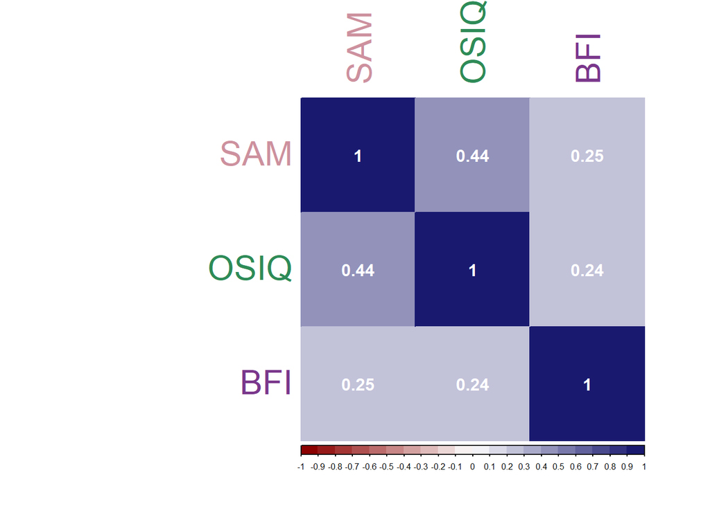

2. Correlation Plot

SAM and OSIQ show stronger correlation with each other than BFI. The Blue blocks along the diagonal shows how the questions are correlated with each other. The black lines separate the tables.

- Episodic and Future memory questions(SAM) have stronger positive correlation with object imagery questions(OSIQ) and also show positive correlation with openness , extroversion and agreeableness questions(BFI)
- Neurotism(BFI) seems strongly negatively correlated with extroversion (BFI), however it is also slightly negatively correlated with all other set of questions.

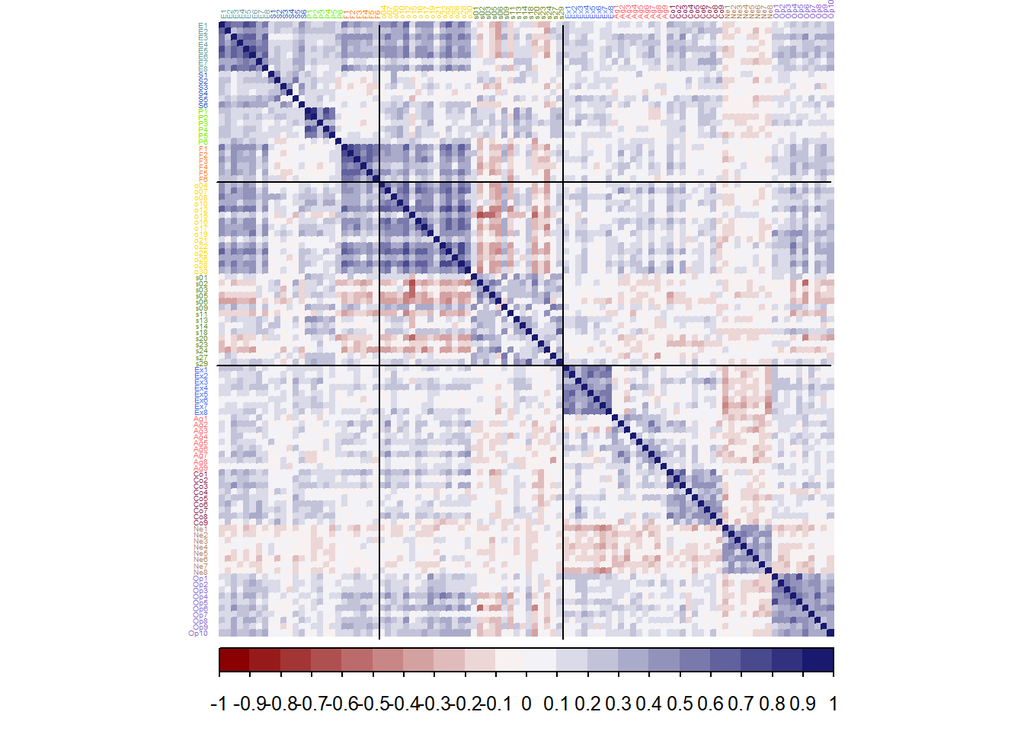

```r
XYZ.cor <- cor(data_MFA)


corrplot(XYZ.cor, method = "color",tl.col = col4combined,tl.cex = .3, cl.pos ='b',
         col = colorRampPalette(c("darkred", "white","midnightblue"))(20)
          )

lines(c(26.5, 26.5), c(0,100 ), lwd=1, lty=1)
lines(c(56.5, 56.5), c(0,100), lwd=1, lty=1)
lines(c(0,100),c(44.5, 44.5), lwd=1, lty=1)
lines(c(0,100),c(74.5, 74.5), lwd=1, lty=1)
```

NOTE:

```
MFA Weights applied to each table = 1/(singular value of first component of that table)
Weight is the scaler value applied such that all the three tables equally contribute towards the dimension 1.
```

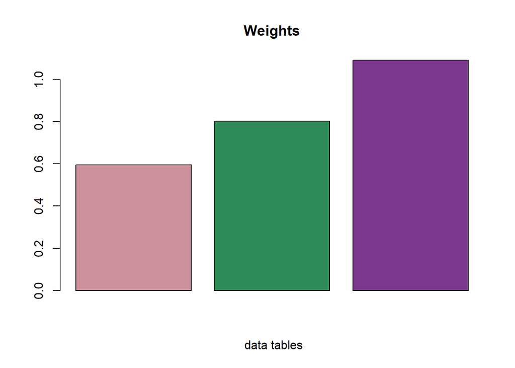

### Scree Plot

Note: Dimension 3 and 4 form an eigen plane so it is better to look at these dimensions together.

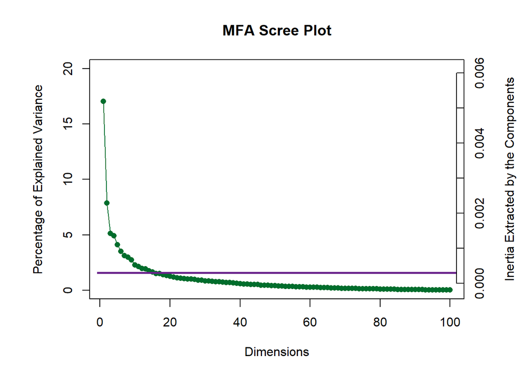

```
## [1] 0.000 0.001 0.002 0.003 0.004 0.005 0.006
```

### Global Row Factor scores:

Dimension 1 represents the seperation of the High Autobiographical memory group from the low which transitions from one group to another along the axis. The means are significantly separate from each other.

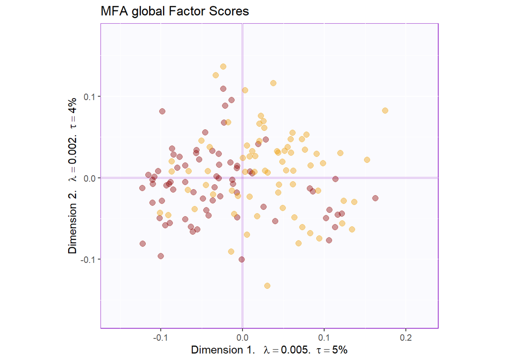

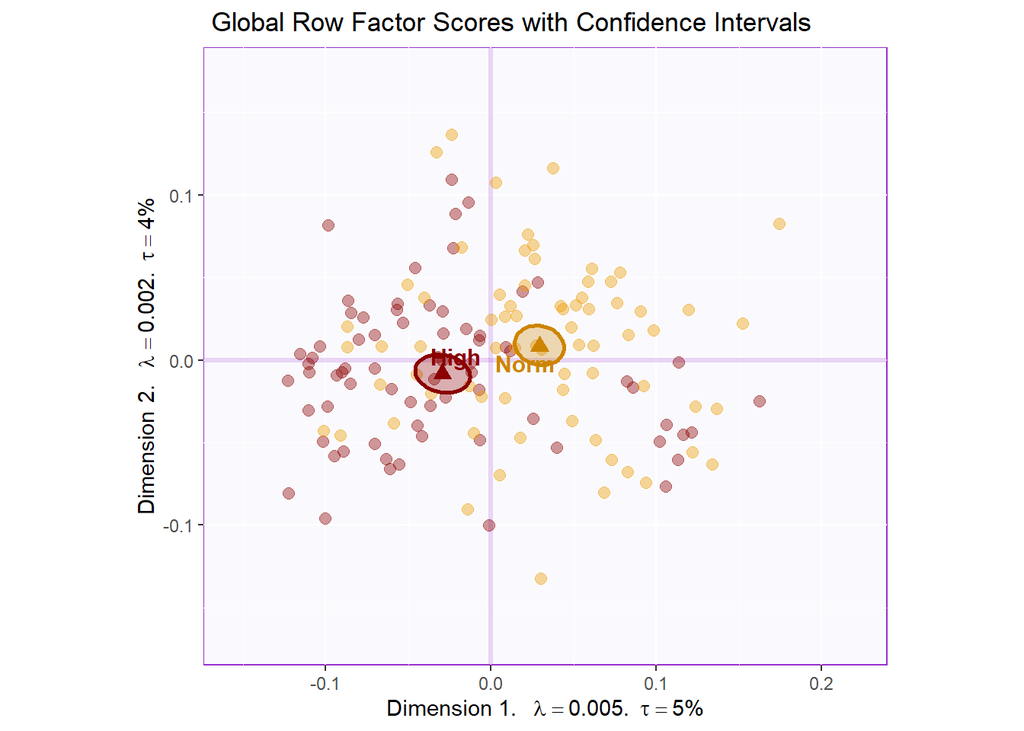

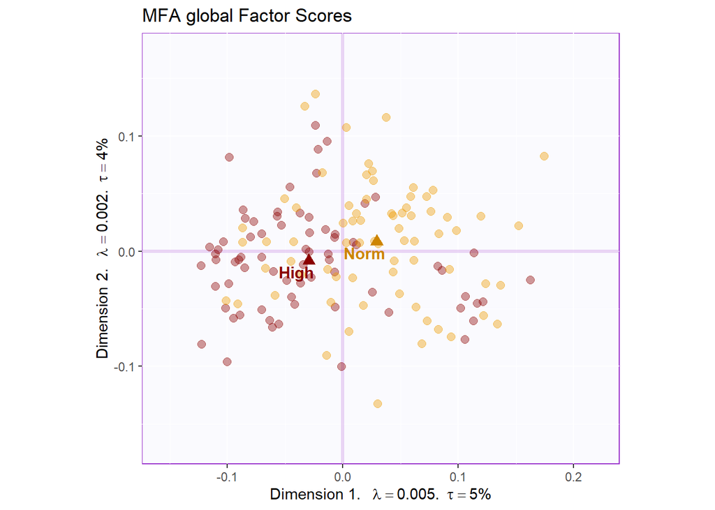

Partial factor scores:

SAM is least distant from the mean than BFI and OSIQ.

```r
F_j<- res.mfa$mexPosition.Data$Table$partial.fi.array

res.mfa$mexPosition.Data$InnerProduct$alphaWeights
```

```
##           [,1]      [,2]      [,3]
## [1,] 0.3333333 0.3333333 0.3333333
```

```r
Eig.tab <- res.mfa$mexPosition.Data$Compromise$compromise.eigs
alpha_j <- 1/sqrt(Eig.tab)

data_tables<- col.design
code4Groups<- unique(data_tables)
nK<- length(code4Groups)


F_k <- array(0, dim = c(dim(F_j)[[1]], dim(F_j)[[2]],nK))
dimnames(F_k) <- list(dimnames(F_j)[[1]], dimnames(F_j)[[2]], code4Groups)

alpha_k <- rep(0, nK)
names(alpha_k) <- code4Groups
Fa_j <- F_j

# A horrible loop
for (j in 1:dim(F_j)[[3]]){ Fa_j[,,j] <- F_j[,,j] * alpha_j[j] }

# Another horrible loop
for (k in 1:nK){
 # lindex <- data_tables == code4Groups[k]
  alpha_k[k] <- alpha_j[k]
  F_k[,,k] <- (1/alpha_k[k])*apply(Fa_j[,,k],c(1,2),sum)

}



meanfk <-
  apply(F_k, c(2,3), FUN = function(x){
  aggregate(x, by = list(row.design), mean)$x
  })
dim(meanfk)
```

```
## [1]   2 100   3
```

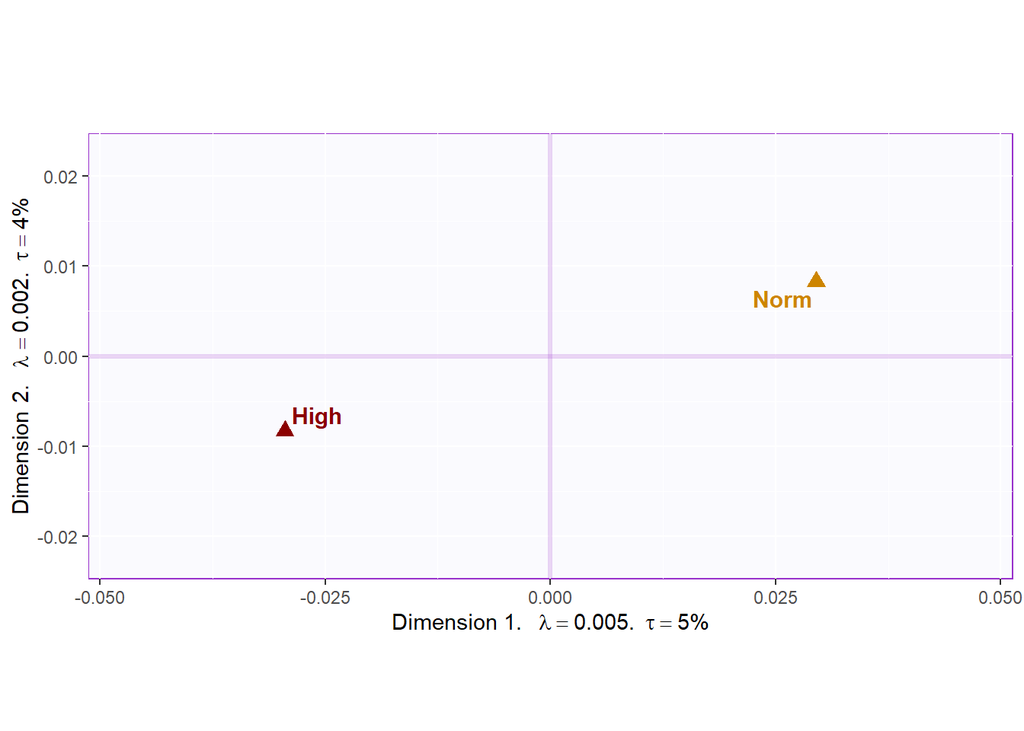

```r
 mean.plot <- createFactorMap(fi.mean,
                                constraints = minmaxHelper4Partial(fi.mean, meanfk, axis1 = 1 ,axis2 = 2) ,
                              alpha.points = 1,
                                display.labels = TRUE,
                                col.points = col4means,
                                col.labels = col4means,
                                pch = 17,
                                cex = 3,
                                text.cex = 4
                                )

Fi.meanonly.plot<- mean.plot$zeMap_background+mean.plot$zeMap_dots + mean.plot$zeMap_text+ label4Map.mfa

Fi.meanonly.plot
```

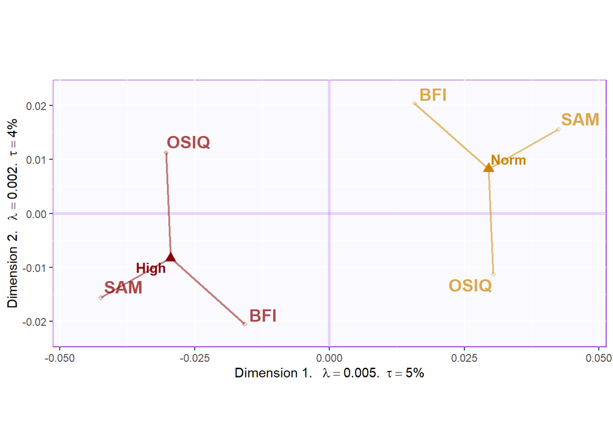

```r
pf.means <- createPartialFactorScoresMap(
                                        factorScores = fi.mean,
                                        partialFactorScores = meanfk,
                                        axis1 = 1, axis2 = 2,
                                        colors4Items = as.vector(col4means),
colors4Blocks = c("green3", "maroon4","midnightblue"),
                                        names4Partial = c("SAM", "OSIQ","BFI"), #
                                        font.labels = 'bold',
                                        size.labels = 5,
)

plot.pFi.mean <- Fi.meanonly.plot + label4Map.mfa + pf.means$mapColByItems
plot.pFi.block <- Fi.meanonly.plot + label4Map.mfa +pf.means$mapColByBlocks
plot.pFi.mean
```

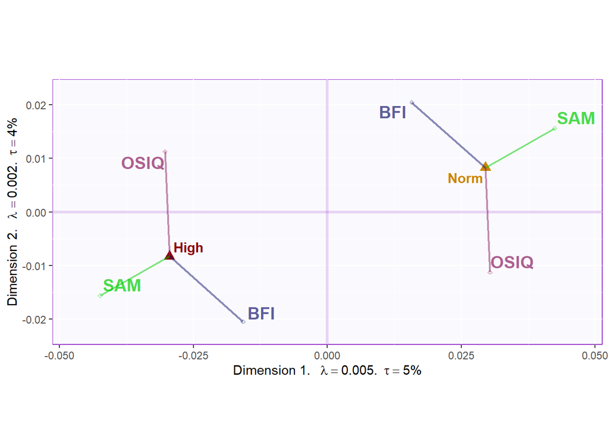

```r
plot.pFi.block
```

### Column Factor scores

Dim1: Better the memory for personal experiences and future memory , more openness and better object imagery Dim2: Better the spatial memory, better is their Spatial imagery more the Extroversion and contrasts with Neurotism

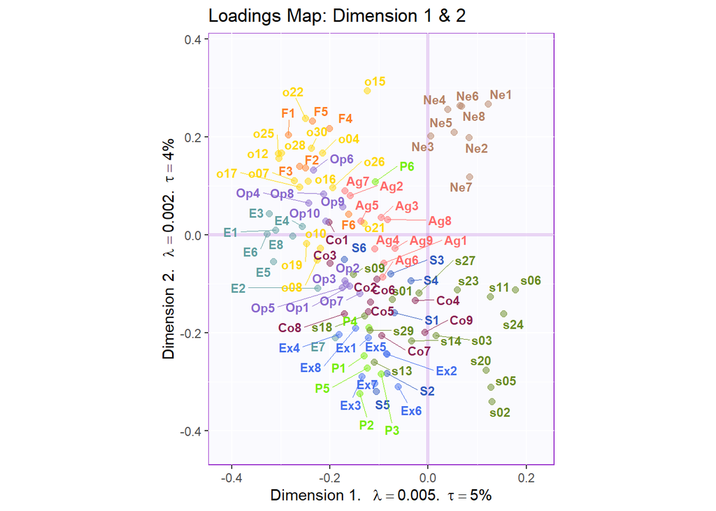

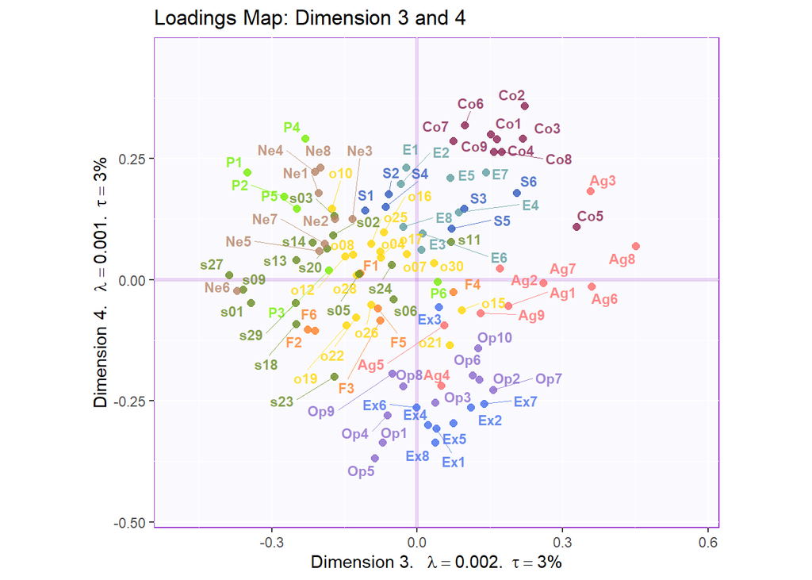

### Column Contribution

Grid Plot with Contribution and Bootstrap Ratios:

[figure not shown]

## Conclusion:

Dim1: Participants under the High AM group are likely to have better memory for personal experiences and future memory, as well as they tend to show more openness and have a preference towards object imagery.

Dim2: Better the spatial memory, better is their Spatial imagery more the Extroversion and contrasts with Neurotism